# Homework

Deyu He

2023-12-04

```r
library(ggplot2)
library(bootstrap)
library(boot)
library(R2OpenBUGS)
library(DAAG)
library(Rcpp)
```

## Question

Use your knowledge to write three or more examples, including figures or tables, or better yet, mathematical formulas.

## Answer

example 1:

The first example describes the ratio of men to women in my master’s class

```r
#Number of male and female students in the master's class
x = c(13,32)
#Enter labels
ns = c("women","men")
#Enter colors
cs = c("blue","lightgray")
#Draw a 3D pie chart
pie3D(x,labels = ns,explode = 0.1,col = cs,main = "examples 1.1")
#Draw a flat pie chart
pie(x,labels = ns,col = cs,main = "examples 1.2")
```

[output not shown]

example 2:

Plot a table of coefficients of the regression equation for y = x^3

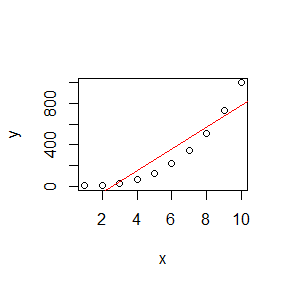

```r
x <- 1:10
y <- x^3
lmr <- lm(y~x)
co <- summary(lmr)$coefficients
title <- expression(y == x^3)
result <- knitr::kable(co,digits = 2,align = 'c')
plot(x,y)
abline(lmr,col="red")
```

```r
result
```

|  | Estimate | Std. Error | t value | Pr(>\|t\|) |
| --- | --- | --- | --- | --- |
| (Intercept) | -277.2 | 92.55 | -3.00 | 0.02 |
| x | 105.4 | 14.92 | 7.07 | 0.00 |

example 3:

Map the distribution of experience.Data is arbitrary data.

```r
dat <- c(10,22,30,40,55,56,80,94)
fun_table <- function(x){x <- sort(x)
n <- length(x)
tab <- unname(c(table(x)))
pct = tab / n
d <- data.frame(x = sort(unique(x)),freq = tab,pct = pct,cumfreq = cumsum(tab),cumpct = cumsum(pct))
}
knitr::kable(fun_table(dat),align = 'c')
```

| x | freq | pct | cumfreq | cumpct |
| --- | --- | --- | --- | --- |
| 10 | 1 | 0.125 | 1 | 0.125 |
| 22 | 1 | 0.125 | 2 | 0.250 |
| 30 | 1 | 0.125 | 3 | 0.375 |
| 40 | 1 | 0.125 | 4 | 0.500 |
| 55 | 1 | 0.125 | 5 | 0.625 |
| 56 | 1 | 0.125 | 6 | 0.750 |
| 80 | 1 | 0.125 | 7 | 0.875 |
| 94 | 1 | 0.125 | 8 | 1.000 |

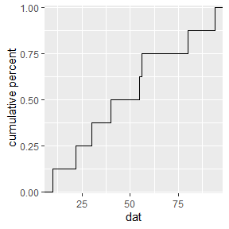

```r
d <- data.frame(dat)
datafre <- fun_table(d$dat)
pic <- ggplot(data = datafre,mapping = aes(x=dat,y=cumpct))
pic +stat_ecdf(geom = "step") +
scale_y_continuous(
limits = c(-.01, 1.01),
expand = c(0, 0),
name = " cumulative percent")
```

## Question

Inverse transformation method is used to reproduce some parameter functions of the Sample function

## Answer

In this chunk,reproduce the function of argument “replace” in sample.

```r
#Take the same parameters as the sample function
newsample <- function(x,size,replace = FALSE,prob = NULL){
  if (replace == TRUE){         #sample with replacement
    A <- runif(size,1,length(x))#sampling from uniform distribution
    B <- round(A)               #round random numbers to  indexs
    y <- x[B]
  }
  else if (size <= length(x) & replace == FALSE){  #sample without replacement
    n <- size;
    k <- 0;                     #sampled numbers
    y <- c(1:size);             #The while loop replaces elements in y with elements in x
    Results <- 1:size
    while (k<n){
      D <- runif(1,1,length(x))
      E <- round(D)
      #removes the taken element from x
      if (E %in% Results){
        k <- k + 1
        Results <- Results[-which(Results==E)]
        y[k] <- x[E]
      }
    }
  }
  else {              #Except for the above two methods, the rest will report errors
    y <- "input error"
  }
  return(y)
}
#Compare the two functions sample and newsample
newsample(c(1,3,2,4,5),5) #Sampling without replacement
```

```
## [1] 1 2 3 4 5
```

```r
newsample(1:2,5,replace = TRUE) #Sampling with replacement
```

```
## [1] 2 1 2 2 1
```

```r
sample(c(1,3,2,4,5),5)
```

```
## [1] 4 2 3 1 5
```

```r
sample(1:2,5,replace=TRUE)
```

```
## [1] 1 2 1 2 2
```

## Question

Use the inverse transform method to generate a random sample of size 1000 from Laplace distribution.Compare the generated sample to the distribution

## Answer

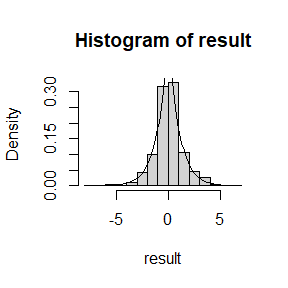

```r
set.seed(1234)
n <- 1000
result <- vector()   #generate numbers
u <- runif(n)
k <- 0
#Divide the generated u into two situations
while (k<n){
   k <- k+1
   if (0<u[k] & u[k]<=0.5){
     result[k] <- log(2*u[k])
   }
   else {
     result[k] <- -log(2*(1-u[k]))
   }
}
hist(result,prob = TRUE)
y <- seq(-5,5,0.1)
z <- exp(-abs(y))/2
lines(y,z)
```

## Question

Write a function to generate a random sample of size n from the Beta(a, b) distribution by the acceptance-rejection method. Generate a random sample of size 1000 from the Beta(3,2) distribution. Graph the histogram of the sample with the theoretical Beta(3,2) density superimposed.

## Answer

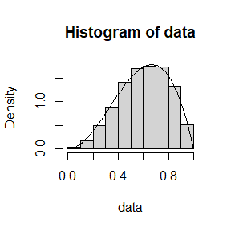

```r
# creat the function
betasample <- function(n,a,b){
  samplenum <- n
  k <- 0
  result <- vector()
  while (k < samplenum){
    u <- runif(1) #define U
    x <- runif(1) #define g(x)
    if (x^(a-1)*(1-x)^(b-1) > u){ #define c = gamma(a+b)/(gamma(a)+gamma(b))
      k <- k + 1
      result[k] <- x
    }
  }
  return(result)
}

#generate 1000 samples from the Beta distribution and draw the histogram with theoretical Beta(3,2) density
n <- 1000
data <- betasample(n,3,2)
hist(data,prob = TRUE)
x <- seq(0,1,0.1)
curve(dbeta(x,3,2),add = TRUE)
```